# act_report

Insight Using twitter_archive_master.name.value_counts() I was able to determine the dog names with the most common occurrence. Cooper, Charlie, Oliver have the highest occurrence with Cooper at the top with 9 occurrence while Charlie and Oliver are 2nd and 3rd r with occurrence of 8 and 7 respectively. Walter, Dale and Rizzo are bottom 3 in terms of occurrence, with each appearing once. Secondly, I used twitter_archive_master.category.value_counts() to find out number of occurrence of each category. The data was as follows: Pupper occurred 70 times and was the leading followed by doggo 24 times, then puppo 13 times, then floofer 4 times , then doggo pupper 3 times. Thirdly, I used twitter_archive_master.groupby('name')['favorite_count'].sum().sort_values(ascending=False)to find dog which had the highest favorite count. The results were as follows: Top 4 Bo had highest favorite counts which were 136148 Zoey had the second highest which were 113237 Duddles had third highest which were 107956 favorite counts Stephan and Jamesy had forth and fifth favorite count at 107015 and 106827 respectively. On Bo’s case, we can assume that number of occurrence might have an impact on favorite count. Dog names with list favorite counts were: Keneth at 234 favorite count Keet at 227 favorite count Fwed at 211 favorie count Christopher at 190 favorite count And the least is Walter at 129 favorite count. Also on Christopher's case we can assume that maybe the 1 time number of occurrence affected favorite count

```python
Visualization
```

For Visualization, I plotted above bar which showed that Pupper occured more times than other categories

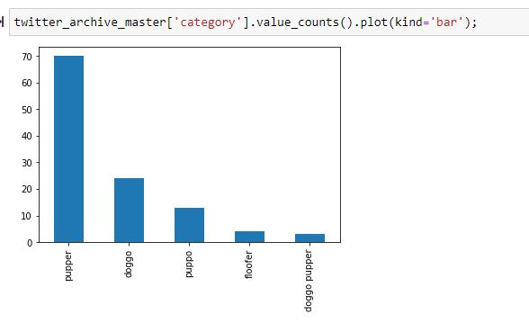